# Prosper Loan Data Analysis

## Introduction

This project explores a dataset from Prosper. Prosper is a peer-to-peer lending company where individuals can either invest in personal loans or request to borrow money. The dataset contains 113,937 personal loan records with 81 variables in each loan record.

## Preliminary Wrangling

```python
# import all packages and set plots to be embedded inline
import numpy as np
import pandas as pd
import matplotlib.pyplot as plt
import seaborn as sns

sns.set_style('darkgrid')
sns.set_context('notebook', rc={"font.size":12,"axes.titlesize":16,"axes.labelsize":12})
%matplotlib inline

# suppress warnings from final output
import warnings
warnings.simplefilter("ignore")
```

```python
# loading prosperLoanData.csv as a dataframe
df = pd.read_csv('data\prosperLoanData.csv')
df
```

|  | ListingKey | ListingNumber | ListingCreationDate | CreditGrade | Term | LoanStatus | ClosedDate | BorrowerAPR | BorrowerRate | LenderYield | ... | LP_ServiceFees | LP_CollectionFees | LP_GrossPrincipalLoss | LP_NetPrincipalLoss | LP_NonPrincipalRecoverypayments | PercentFunded | Recommendations | InvestmentFromFriendsCount | InvestmentFromFriendsAmount | Investors |
| --- | --- | --- | --- | --- | --- | --- | --- | --- | --- | --- | --- | --- | --- | --- | --- | --- | --- | --- | --- | --- | --- |
| 0 | 1021339766868145413AB3B | 193129 | 2007-08-26 19:09:29.263000000 | C | 36 | Completed | 2009-08-14 00:00:00 | 0.16516 | 0.1580 | 0.1380 | ... | -133.18 | 0.0 | 0.0 | 0.0 | 0.0 | 1.0 | 0 | 0 | 0.0 | 258 |
| 1 | 10273602499503308B223C1 | 1209647 | 2014-02-27 08:28:07.900000000 | NaN | 36 | Current | NaN | 0.12016 | 0.0920 | 0.0820 | ... | 0.00 | 0.0 | 0.0 | 0.0 | 0.0 | 1.0 | 0 | 0 | 0.0 | 1 |
| 2 | 0EE9337825851032864889A | 81716 | 2007-01-05 15:00:47.090000000 | HR | 36 | Completed | 2009-12-17 00:00:00 | 0.28269 | 0.2750 | 0.2400 | ... | -24.20 | 0.0 | 0.0 | 0.0 | 0.0 | 1.0 | 0 | 0 | 0.0 | 41 |
| 3 | 0EF5356002482715299901A | 658116 | 2012-10-22 11:02:35.010000000 | NaN | 36 | Current | NaN | 0.12528 | 0.0974 | 0.0874 | ... | -108.01 | 0.0 | 0.0 | 0.0 | 0.0 | 1.0 | 0 | 0 | 0.0 | 158 |
| 4 | 0F023589499656230C5E3E2 | 909464 | 2013-09-14 18:38:39.097000000 | NaN | 36 | Current | NaN | 0.24614 | 0.2085 | 0.1985 | ... | -60.27 | 0.0 | 0.0 | 0.0 | 0.0 | 1.0 | 0 | 0 | 0.0 | 20 |
| ... | ... | ... | ... | ... | ... | ... | ... | ... | ... | ... | ... | ... | ... | ... | ... | ... | ... | ... | ... | ... | ... |
| 113932 | E6D9357655724827169606C | 753087 | 2013-04-14 05:55:02.663000000 | NaN | 36 | Current | NaN | 0.22354 | 0.1864 | 0.1764 | ... | -75.58 | 0.0 | 0.0 | 0.0 | 0.0 | 1.0 | 0 | 0 | 0.0 | 1 |
| 113933 | E6DB353036033497292EE43 | 537216 | 2011-11-03 20:42:55.333000000 | NaN | 36 | FinalPaymentInProgress | NaN | 0.13220 | 0.1110 | 0.1010 | ... | -30.05 | 0.0 | 0.0 | 0.0 | 0.0 | 1.0 | 0 | 0 | 0.0 | 22 |
| 113934 | E6E13596170052029692BB1 | 1069178 | 2013-12-13 05:49:12.703000000 | NaN | 60 | Current | NaN | 0.23984 | 0.2150 | 0.2050 | ... | -16.91 | 0.0 | 0.0 | 0.0 | 0.0 | 1.0 | 0 | 0 | 0.0 | 119 |
| 113935 | E6EB3531504622671970D9E | 539056 | 2011-11-14 13:18:26.597000000 | NaN | 60 | Completed | 2013-08-13 00:00:00 | 0.28408 | 0.2605 | 0.2505 | ... | -235.05 | 0.0 | 0.0 | 0.0 | 0.0 | 1.0 | 0 | 0 | 0.0 | 274 |
| 113936 | E6ED3600409833199F711B7 | 1140093 | 2014-01-15 09:27:37.657000000 | NaN | 36 | Current | NaN | 0.13189 | 0.1039 | 0.0939 | ... | -1.70 | 0.0 | 0.0 | 0.0 | 0.0 | 1.0 | 0 | 0 | 0.0 | 1 |

113937 rows × 81 columns

```python
# data shape
df.shape
```

```
(113937, 81)
```

```python
df.info()
```

```
<class 'pandas.core.frame.DataFrame'>
RangeIndex: 113937 entries, 0 to 113936
Data columns (total 81 columns):
 #   Column                               Non-Null Count   Dtype
---  ------                               --------------   -----
 0   ListingKey                           113937 non-null  object
 1   ListingNumber                        113937 non-null  int64
 2   ListingCreationDate                  113937 non-null  object
 3   CreditGrade                          28953 non-null   object
 4   Term                                 113937 non-null  int64
 5   LoanStatus                           113937 non-null  object
 6   ClosedDate                           55089 non-null   object
 7   BorrowerAPR                          113912 non-null  float64
 8   BorrowerRate                         113937 non-null  float64
 9   LenderYield                          113937 non-null  float64
```

[output cut: 73 more lines]

```python
# summary statistics
df.describe()
```

|  | ListingNumber | Term | BorrowerAPR | BorrowerRate | LenderYield | EstimatedEffectiveYield | EstimatedLoss | EstimatedReturn | ProsperRating (numeric) | ProsperScore | ... | LP_ServiceFees | LP_CollectionFees | LP_GrossPrincipalLoss | LP_NetPrincipalLoss | LP_NonPrincipalRecoverypayments | PercentFunded | Recommendations | InvestmentFromFriendsCount | InvestmentFromFriendsAmount | Investors |
| --- | --- | --- | --- | --- | --- | --- | --- | --- | --- | --- | --- | --- | --- | --- | --- | --- | --- | --- | --- | --- | --- |
| count | 1.139370e+05 | 113937.000000 | 113912.000000 | 113937.000000 | 113937.000000 | 84853.000000 | 84853.000000 | 84853.000000 | 84853.000000 | 84853.000000 | ... | 113937.000000 | 113937.000000 | 113937.000000 | 113937.000000 | 113937.000000 | 113937.000000 | 113937.000000 | 113937.000000 | 113937.000000 | 113937.000000 |
| mean | 6.278857e+05 | 40.830248 | 0.218828 | 0.192764 | 0.182701 | 0.168661 | 0.080306 | 0.096068 | 4.072243 | 5.950067 | ... | -54.725641 | -14.242698 | 700.446342 | 681.420499 | 25.142686 | 0.998584 | 0.048027 | 0.023460 | 16.550751 | 80.475228 |
| std | 3.280762e+05 | 10.436212 | 0.080364 | 0.074818 | 0.074516 | 0.068467 | 0.046764 | 0.030403 | 1.673227 | 2.376501 | ... | 60.675425 | 109.232758 | 2388.513831 | 2357.167068 | 275.657937 | 0.017919 | 0.332353 | 0.232412 | 294.545422 | 103.239020 |
| min | 4.000000e+00 | 12.000000 | 0.006530 | 0.000000 | -0.010000 | -0.182700 | 0.004900 | -0.182700 | 1.000000 | 1.000000 | ... | -664.870000 | -9274.750000 | -94.200000 | -954.550000 | 0.000000 | 0.700000 | 0.000000 | 0.000000 | 0.000000 | 1.000000 |
| 25% | 4.009190e+05 | 36.000000 | 0.156290 | 0.134000 | 0.124200 | 0.115670 | 0.042400 | 0.074080 | 3.000000 | 4.000000 | ... | -73.180000 | 0.000000 | 0.000000 | 0.000000 | 0.000000 | 1.000000 | 0.000000 | 0.000000 | 0.000000 | 2.000000 |
| 50% | 6.005540e+05 | 36.000000 | 0.209760 | 0.184000 | 0.173000 | 0.161500 | 0.072400 | 0.091700 | 4.000000 | 6.000000 | ... | -34.440000 | 0.000000 | 0.000000 | 0.000000 | 0.000000 | 1.000000 | 0.000000 | 0.000000 | 0.000000 | 44.000000 |
| 75% | 8.926340e+05 | 36.000000 | 0.283810 | 0.250000 | 0.240000 | 0.224300 | 0.112000 | 0.116600 | 5.000000 | 8.000000 | ... | -13.920000 | 0.000000 | 0.000000 | 0.000000 | 0.000000 | 1.000000 | 0.000000 | 0.000000 | 0.000000 | 115.000000 |
| max | 1.255725e+06 | 60.000000 | 0.512290 | 0.497500 | 0.492500 | 0.319900 | 0.366000 | 0.283700 | 7.000000 | 11.000000 | ... | 32.060000 | 0.000000 | 25000.000000 | 25000.000000 | 21117.900000 | 1.012500 | 39.000000 | 33.000000 | 25000.000000 | 1189.000000 |

8 rows × 61 columns

```python
# removing borrower records > 25000 and IncomeRange == Not Displayed & Not Employed
df = df.query('StatedMonthlyIncome <= 25000 & IncomeRange != ["Not employed", "Not displayed", "$0"]')
```

```python
# replacing past due values with one value
past_due = ['Past Due (1-15 days)', 'Past Due (16-30 days)', 'Past Due (31-60 days)',
                 'Past Due (61-90 days)', 'Past Due (91-120 days)', 'Past Due (>120 days)']

df['LoanStatus'] = df['LoanStatus'].replace(past_due, 'Past Due')
```

```python
# changing LoanStatus, ProsperScore and IncomeRange into ordered categorical data types
ordered_category_dict = {'LoanStatus' : ['Cancelled', 'Chargedoff', 'Completed', 'Current', 'Defaulted',
                 'FinalPayementProgress', 'Past Due'],
                 'ProsperScore' : [1, 2, 3, 4, 5, 6, 7, 8, 9, 10],
                 'IncomeRange' : ['$1-24,999', '$25,000-49,999', '$50,000-74,999', '$75,000-99,999', '$100,000+',]}

for i in ordered_category_dict:
    ordered_category = pd.api.types.CategoricalDtype(ordered=True, categories=ordered_category_dict[i])
    df[i] = df[i].astype(ordered_category)
```

### What is the structure of your dataset?

The dataset contains 81 columns (variables) and 113937 rows (observations). 61 variables are numeric in nature. The dataset is also divided into borrowers details, lender specifications and loan details.

### What is/are the main feature(s) of interest in your dataset?

I'm interested in finding out what features best predict the number of Investors for a loan in the dataset. Also, how BorrowerRate and LenderYield relate with other features.

### What features in the dataset do you think will help support your investigation into your feature(s) of interest?

I think LoanOriginalAmount will have a big impact on Investors, such that a high LoanOriginalAmount will have a high number of Investors and vice versa. I also expect other features such as BorrowerRate and IncomeRange will have an effect on the number of Investors.

## Univariate Exploration

I'll begin with the main variable of interest: Investors.

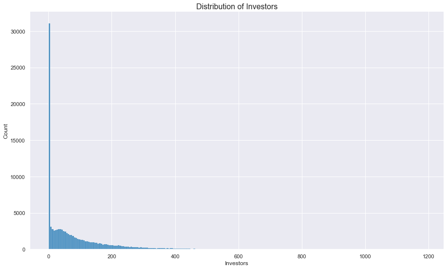

```python
# normal scale histogram plot
sns.displot(df['Investors']).set(title='Distribution of Investors')
plt.gcf().set_size_inches(15, 8)
```

[figure not shown]

```python
# the distribution is highly skewed, let's try the log scale
p = sns.displot(np.log10(df['Investors']))
p.set(title='Distribution of Investors')
p.set(xticks=([0.0, 0.5, 1.0, 1.5, 2.0, 2.5, 3.0]))
p.set_xticklabels(['0', '200', '400', '600', '800', '1000', '1200'])
plt.gcf().set_size_inches(15, 8)
```

Next, checking the distribution of LenderYield and BorrowerRate features.

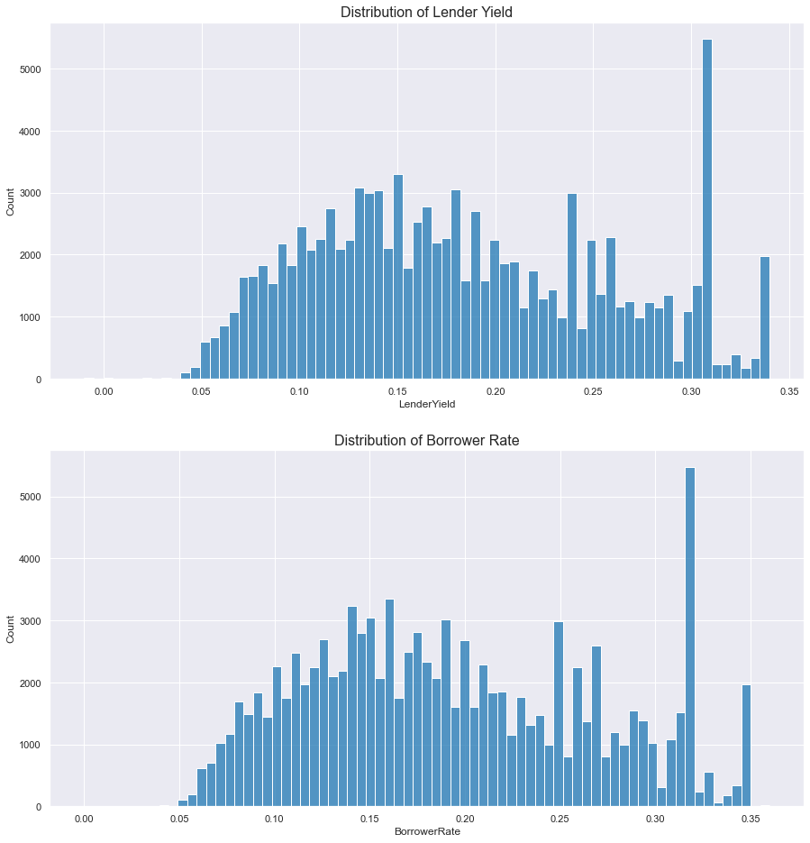

```python
# normal scale histogram plot
fig, ax = plt.subplots(nrows=2, figsize=(15, 16))
sns.histplot(df['LenderYield'], ax=ax[0]).set(title='Distribution of Lender Yield')
sns.histplot(df['BorrowerRate'], ax=ax[1]).set(title='Distribution of Borrower Rate');
```

The LenderYield has a multi modal distribution. There are many peaks in the distribution. There is a huge spike around 0.31 meaning lenders yielded this rate more. BorrowerRate shares a similar distribution to LenderYield, a multimodal distribution with multiple peaks. The highest peak rate also appears around 0.32.

Next is investigating the financial distribution of the borrowers in terms of the loan and income.

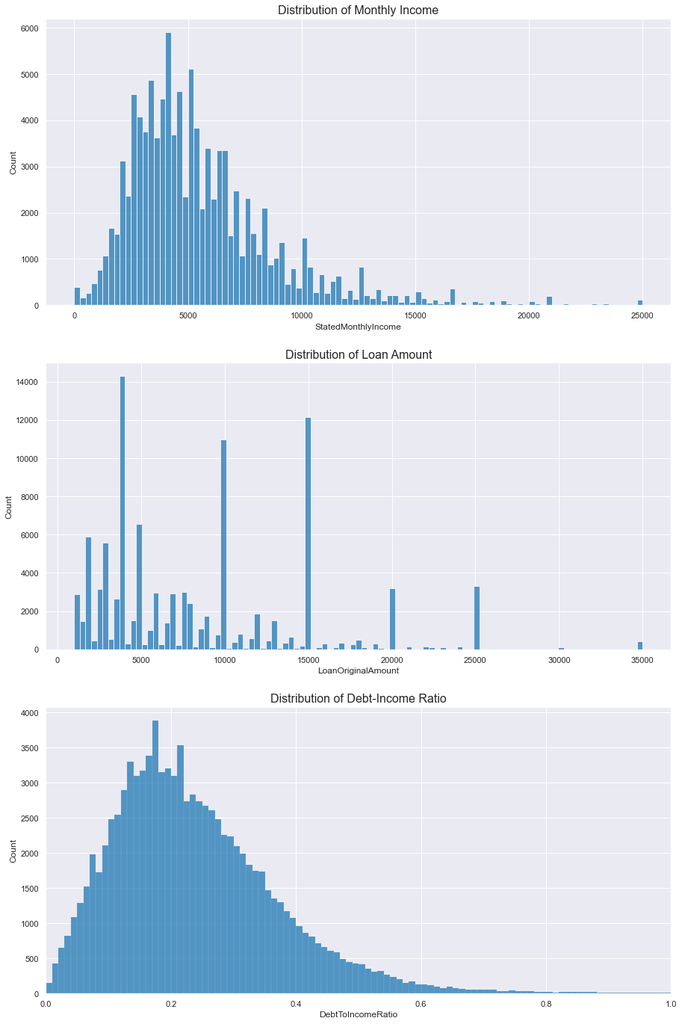

```python
from matplotlib.pyplot import xlim

# histogram subplots
fig, ax = plt.subplots(nrows=3, figsize=(15, 24))

sns.histplot(df['StatedMonthlyIncome'], bins = 100, ax = ax[0]).set(title='Distribution of Monthly Income')
sns.histplot(df['LoanOriginalAmount'], ax = ax[1]).set(title='Distribution of Loan Amount')
sns.histplot(df['DebtToIncomeRatio'], ax = ax[2], bins = 1000).set(title='Distribution of Debt-Income Ratio',
 xlim=(0, 1));
```

Next, on to categorical variables analysis.

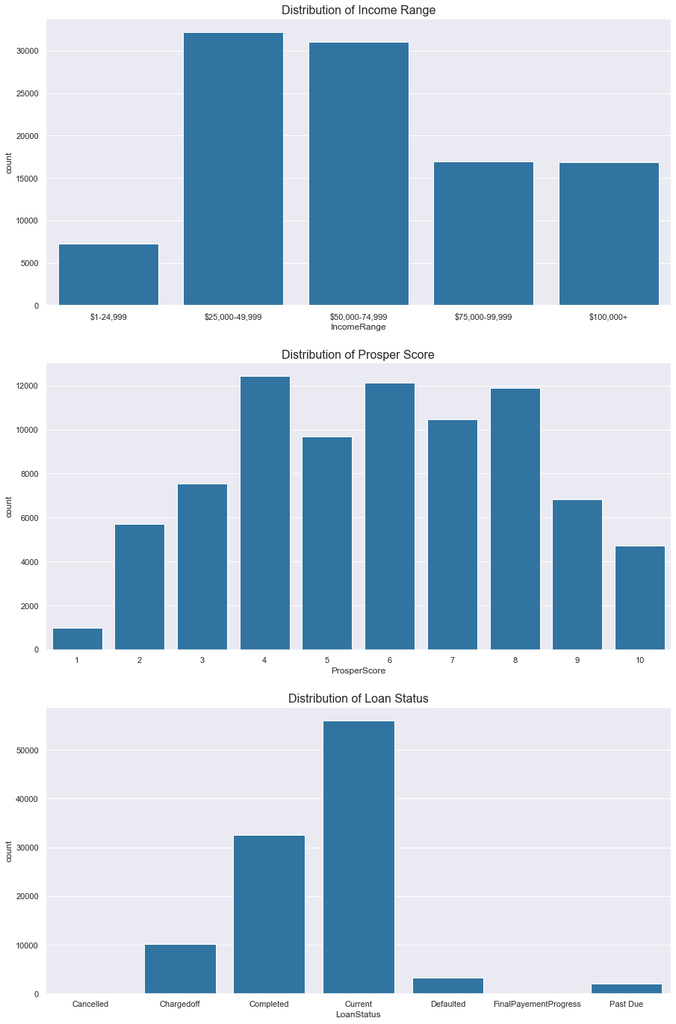

```python
# count plots for categorical variables
fig, ax = plt.subplots(nrows=3, figsize=(15, 24))
default_color = sns.color_palette()[0]
sns.countplot(data = df, x = 'IncomeRange', color = default_color, ax = ax[0])\
    .set(title='Distribution of Income Range')
sns.countplot(data = df, x = 'ProsperScore', color = default_color, ax = ax[1])\
    .set(title='Distribution of Prosper Score')
sns.countplot(data = df, x = 'LoanStatus', color = default_color, ax = ax[2])\
    .set(title='Distribution of Loan Status');
```

### Discuss the distribution(s) of your variable(s) of interest. Were there any unusual points? Did you need to perform any transformations?

The main vairable of interest, Investors, was highly skewed. I had to transform the variable and plot to log scale. There were no unusual points since most of the skewness is as a result of real events, ie. Many loans had one investor.

### Of the features you investigated, were there any unusual distributions? Did you perform any operations on the data to tidy, adjust, or change the form of the data? If so, why did you do this?

From the features, StatedMonthlyIncome and DebtToIncomeRatio had high skewness. StatedMonthlyIncome had high skewness because of people who earn above 25000 caused it so I deceided to include only borrowers who earn less than that. It seems most people from all ranges of borrowers settled on loans less than 20000. Also, I had to change the categorical variables to be in order so as to have organization when plotting.

## Bivariate Exploration

I will check the pairwise correlations between various features in the data.

```python
num_vars = ['Investors', 'LenderYield', 'BorrowerRate', 'StatedMonthlyIncome', 'LoanOriginalAmount', 'DebtToIncomeRatio']
cat_vars = ['IncomeRange', 'ProsperScore', 'LoanStatus']
```

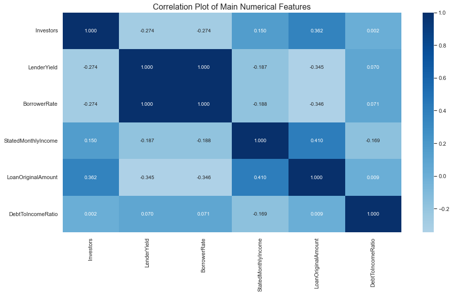

```python
# correlation plot
sns.heatmap(df[num_vars].corr(), cmap="Blues", center = 0, annot = True, fmt = '.3f')\
    .set(title='Correlation Plot of Main Numerical Features')
plt.gcf().set_size_inches(15, 8)
```

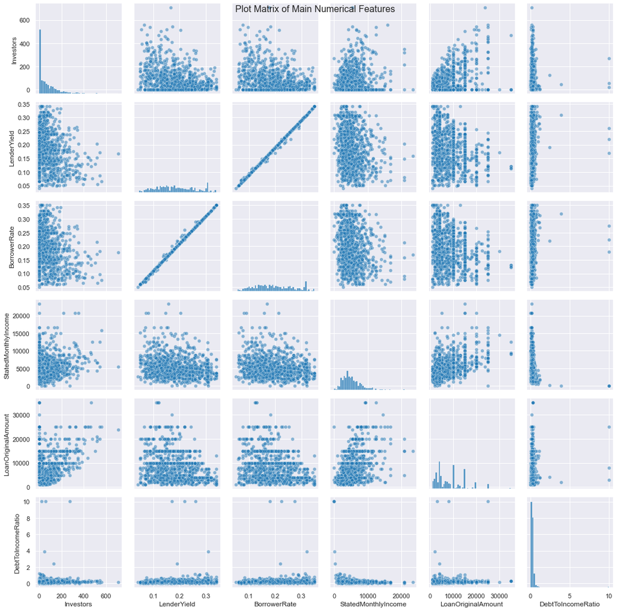

```python
# sampling 500 records and creating a plot matrix
borrower_sample = df.sample(1000)

p = sns.PairGrid(data = borrower_sample, vars = num_vars)
p.fig.suptitle('Plot Matrix of Main Numerical Features', fontsize=16)
p = p.map_diag(sns.histplot, bins = 50)
p.map_offdiag(sns.scatterplot, alpha=0.5);
```

Now, let's look at how the numerical variables correlate with the categorical variables.

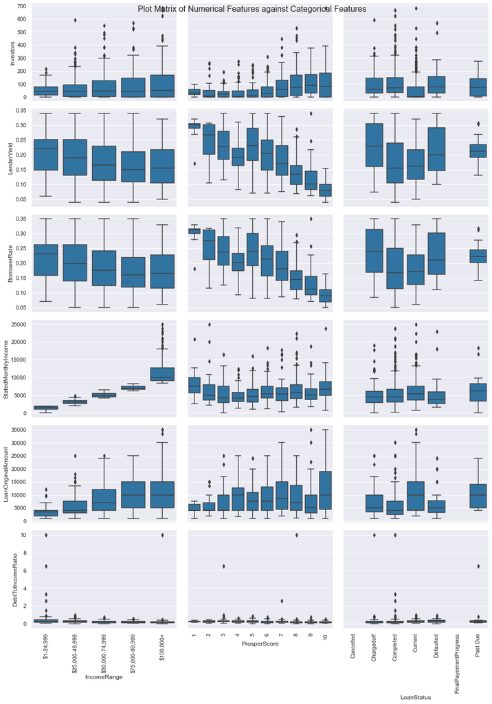

```python
def boxplt(x, y, **kwargs):
    """Creates a box plot inside seaborn's pairgrid"""
    sns.boxplot(x, y, color = default_color)
    plt.xticks(rotation = 90)

p = sns.PairGrid(data = borrower_sample, y_vars = num_vars, x_vars = cat_vars, height = 3, aspect = 1.5)
p.fig.suptitle('Plot Matrix of Numerical Features against Categorical Features', fontsize=16)
p.map(boxplt);
```

It appears that there is some positive correlation between IncomeRange and LoanOriginalAmount. There is also a positive relationship between Investors and ProsperScore as expected. The amount of investors increases as the score rating increases. This is also evident in the positive relationship between ProsperScore and LoanOriginalAmount. LenderYield and BorrowerRate also have a negative correlation with ProsperScore. A higher score rating gives the borrower a low borrow rate for a loan hence returning less yield to the lender.

Let's move on and look at relationships between the categorical features.

```
[Text(0.5, 1.0, 'Loan Status vs Prosper Score')]
```

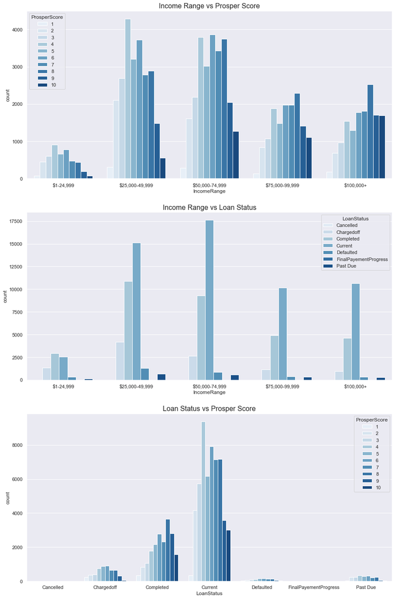

```python
plt.figure(figsize=(15, 24))

# 1st subplot: IncomeRange vs ProsperScore
plt.subplot(3, 1, 1)
sns.countplot(data = df, x = 'IncomeRange', hue = 'ProsperScore', palette = 'Blues')\
    .set(title='Income Range vs Prosper Score')

# 2nd subplot: IncomeRange vs LoanStatus
plt.subplot(3, 1, 2)
sns.countplot(data = df, x = 'IncomeRange', hue = 'LoanStatus', palette = 'Blues')\
    .set(title='Income Range vs Loan Status')

# 3rd subplot: LoanStatus vs ProsperScore
plt.subplot(3, 1, 3)
sns.countplot(data = df, x = 'LoanStatus', hue = 'ProsperScore', palette = 'Blues')\
    .set(title='Loan Status vs Prosper Score')
```

Going back to the correlation pair plot, I'd like to investigate more on the high correlation between BorrowerRate and LenderYield with full data.

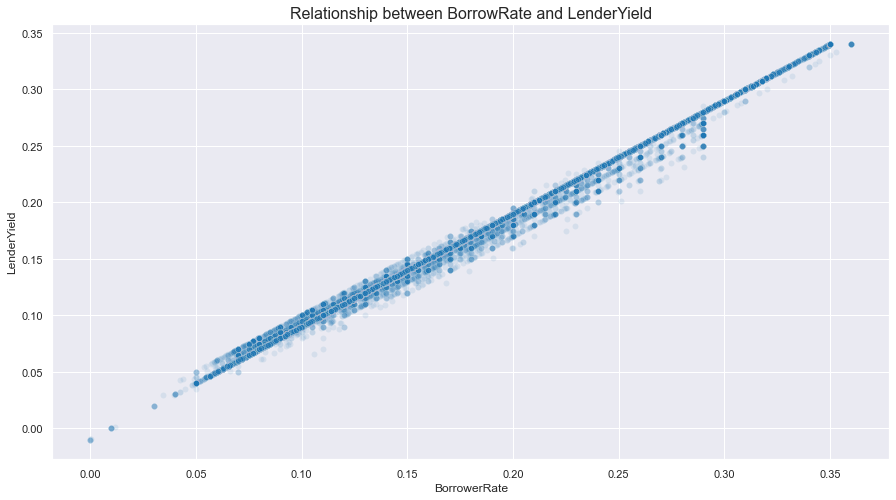

```python
# scatter plot
sns.scatterplot(data = df, x = 'BorrowerRate', y='LenderYield', alpha = 0.1)\
    .set(title='Relationship between BorrowRate and LenderYield')
plt.gcf().set_size_inches(15, 8)
```

Even for all data, there is a strong positive correlation between BorrowerRate and LenderYield. This means that as the borrower rate increases the lenders get a higher yield.

Next, I will investigate the relationship between Investors and LoanOriginalAmount further.

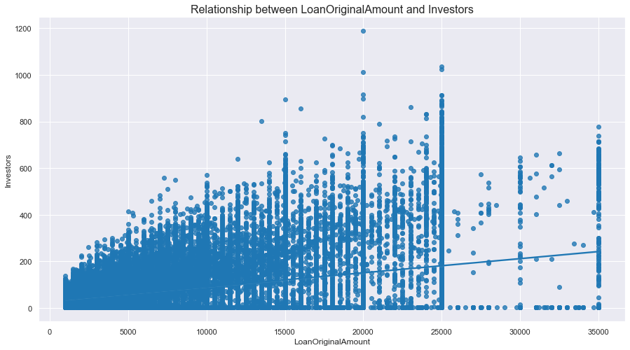

```python
# scatter plot
sns.regplot(data = df, x = 'LoanOriginalAmount', y='Investors')\
    .set(title='Relationship between LoanOriginalAmount and Investors')
plt.gcf().set_size_inches(15, 8)
```

There is a weak positive relationship between LoanOriginalAmount and Investors. LoanOriginalAmount is not sufficient to predict Investors.

### Talk about some of the relationships you observed in this part of the investigation. How did the feature(s) of interest vary with other features in the dataset?

BorrowerRate and LenderYield were highly correlated with one another. LoanOriginalAmount has a decent correlation with Investors compared to the other features.

## Multivariate Exploration

I want to investigate further the relationship of the categorical variables and the main highly correlated features.

```python
def disgrid(x, y, **kwargs):
    """Creating distribution grids with seaborn"""
    palette = kwargs.pop('color')
    plt.hist2d(x, y, bins=20, cmap = palette, cmin = 0.5)
```

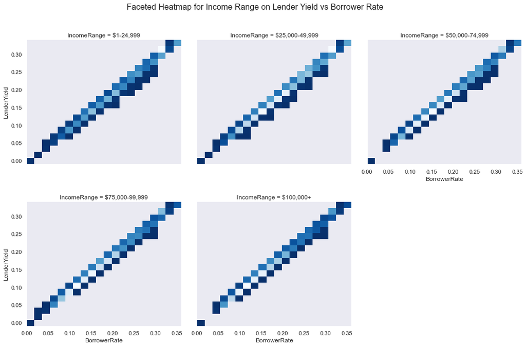

```python
# faceted heatmap for IncomeRange
p = sns.FacetGrid(data = df, col = 'IncomeRange', col_wrap = 3, height = 3)
p.fig.subplots_adjust(top=0.9)
p.fig.suptitle('Faceted Heatmap for Income Range on Lender Yield vs Borrower Rate', fontsize=16)
p.map(disgrid, 'BorrowerRate', 'LenderYield', color='Blues_r')
p.set_xlabels('BorrowerRate')
p.set_ylabels('LenderYield')
plt.gcf().set_size_inches(15, 10)
```

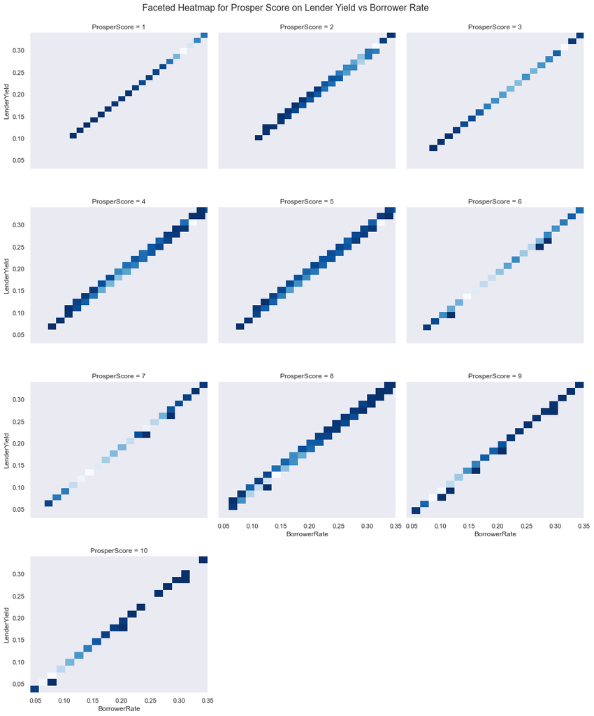

```python
# faceted heatmap for ProsperScore
p = sns.FacetGrid(data = df, col = 'ProsperScore', col_wrap = 3, height = 3)
p.fig.subplots_adjust(top=0.9)
p.fig.suptitle('Faceted Heatmap for Prosper Score on Lender Yield vs Borrower Rate', fontsize=16)
p.map(disgrid, 'BorrowerRate', 'LenderYield', color='Blues_r')
p.set_xlabels('BorrowerRate')
p.set_ylabels('LenderYield')
plt.gcf().set_size_inches(15, 18)
```

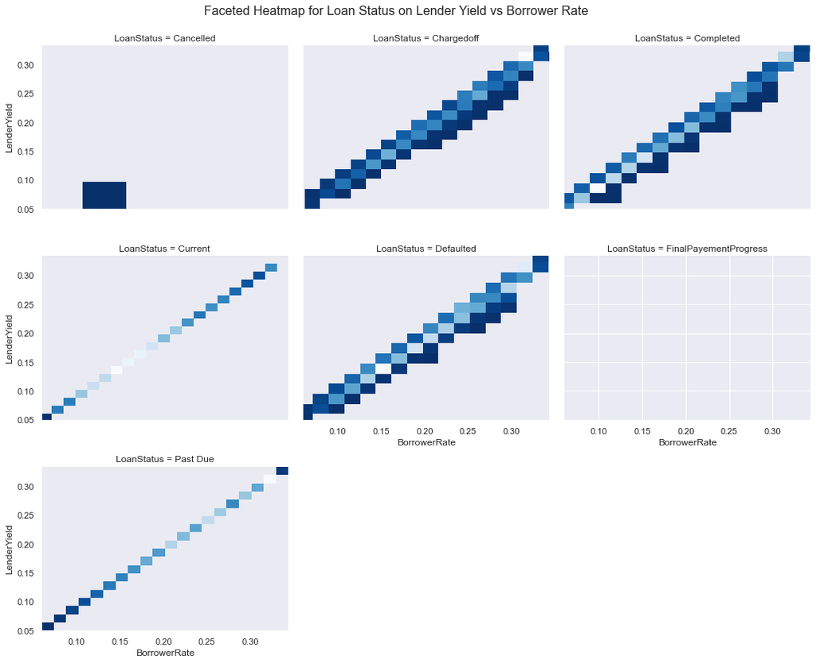

```python
# faceted heatmap for LoanStatus
p = sns.FacetGrid(data = df, col = 'LoanStatus', col_wrap = 3, height = 3)
p.fig.subplots_adjust(top=0.9)
p.fig.suptitle('Faceted Heatmap for Loan Status on Lender Yield vs Borrower Rate', fontsize=16)
p.map(disgrid, 'BorrowerRate', 'LenderYield', color='Blues_r')
p.set_xlabels('BorrowerRate')
p.set_ylabels('LenderYield')
plt.gcf().set_size_inches(15, 12)
```

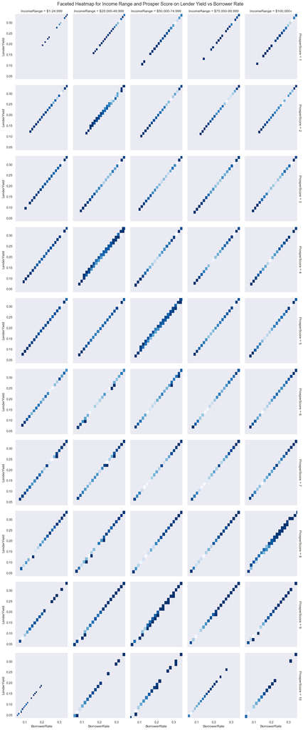

```python
# faceted heatmap for IncomeRange and ProsperScore
p = sns.FacetGrid(data = df, col = 'IncomeRange', row = 'ProsperScore', margin_titles = True, height=2)
p.fig.subplots_adjust(top=0.9)
p.fig.suptitle('Faceted Heatmap for Income Range and Prosper Score on Lender Yield vs Borrower Rate', fontsize=16)
p.map(disgrid, 'BorrowerRate', 'LenderYield', color='Blues_r')
p.set_xlabels('BorrowerRate')
p.set_ylabels('LenderYield')
plt.gcf().set_size_inches(15, 36)
```

The trend can be witnessed again even after plotting the two variables against two different level. This signifies that both BorrowerRate and LenderYield are strongly and positively correlated.

### Talk about some of the relationships you observed in this part of the investigation. Were there features that strengthened each other in terms of looking at your feature(s) of interest?

Both BorrowerRate and LenderYield strengthened each other in terms of their positive relationship. It has been verified by testing their relationship on different levels.

### Were there any interesting or surprising interactions between features?

It was interesting to see both BorrowerRate and LenderYield maintain a strong relationship on different occassions. One can be used to predict the other.

## Conclusions

It was interesting to work with this data and come up with a lot of findings. Some were surprising but despite all, it was important to gain the skills of using visualizations to communicate data findings.

I did a lot of data wrangling and kept coming back to do more after some exploratory data analysis. This is after discovering some outliers that would affect the results of the data.

I was able to plot all kind of visualizations (univariate, bivariate and multivariate) and gained some insights from the visualizations.